# Week 2: Peer-graded Assignment

HK Kim

January 14, 2019

## Peer-graded Assignment: Milestone Report

The goal of this project is just to display that you’ve gotten used to working with the data and that you are on track to create your prediction algorithm. Please submit a report on R Pubs (http://rpubs.com/) that explains your exploratory analysis and your goals for the eventual app and algorithm. This document should be concise and explain only the major features of the data you have identified and briefly summarize your plans for creating the prediction algorithm and Shiny app in a way that would be understandable to a non-data scientist manager. You should make use of tables and plots to illustrate important summaries of the data set. The motivation for this project is to: 1. Demonstrate that you’ve downloaded the data and have successfully loaded it in.2. Create a basic report of summary statistics about the data sets.3. Report any interesting findings that you amassed so far.4. Get feedback on your plans for creating a prediction algorithm and Shiny app.

Review criteria - Does the link lead to an HTML page describing the exploratory analysis of the training data set? - Has the data scientist done basic summaries of the three files? Word counts, line counts and basic data tables? - Has the data scientist made basic plots, such as histograms to illustrate features of the data? - Was the report written in a brief, concise style, in a way that a non-data scientist manager could appreciate?

## Exploratory Analysis

First we take a look at the length of each data

```
## [1] "The length of blogs data: 899288"
```

```
## [1] "The length of news data: 77259"
```

```
## [1] "The length of twitter data: 2360148"
```

Maximum and average Words Per Line for each data

```
## [1] "The maximum words per line for blogs: 6630"
```

```
## [1] "The maximum words per line for news: 1031"
```

```
## [1] "The maximum words per line for twitter: 47"
```

```
## [1] "The average words per line for blogs: 41.5"
```

```
## [1] "The average words per line for news: 34.2"
```

```
## [1] "The average words per line for twitter: 12.9"
```

## Summary Plots

Three histograms below show words count distribution for each data. Vertical line represents the average count number.

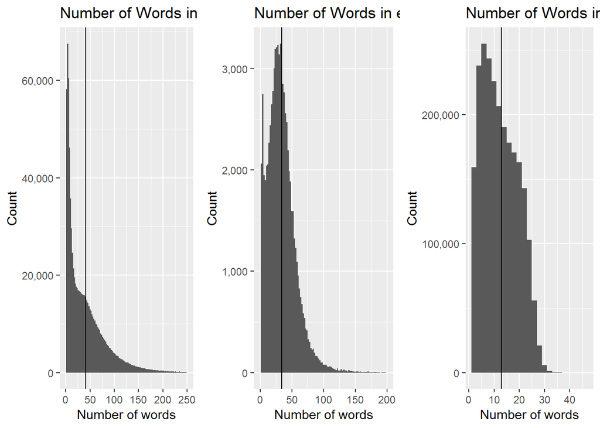

## Sampling and cleaning the data

Take 10% of each data and combine them as the sample dataset, and clean the sample.

## Tokenize & calculate ngram frequencies

```
## Observations: 147
## Variables: 2
## $ word      <fct> for, how, open, tweet, bad, check, though, sinc, som...
## $ frequency <dbl> 3503, 3537, 3573, 3602, 3642, 3643, 3651, 3653, 3676...
```

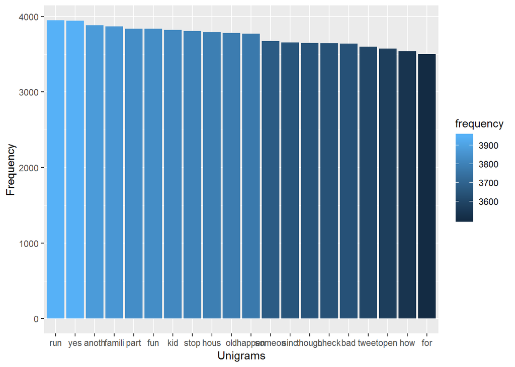

## Conclusion

For this week’s assignment I explored blogs, news and twitter data and took a look at unigrams frequency. Due to technical errors occurred while using “RWeka” package, I could not complete bigrams or trigrams frequency tests as R could not find “NGramTokenizer” function. For the next step I plan on creating a shiny app which predicts following words when a word is typed.